# Numerical Recipies Beetle

Olalla Díaz-Yáñez

2022-07-12

# Aim

This document collects the alternative formulations used to define beetle damage in the model LanClim. This document version has been created to share extra information in the poster presented in the Forest Disturbances and Ecosystem Dynamics in a Changing World 19.09.2022 – 22.09.2022 in Berchtesgaden National Park, Germany.

## The different formulations

The different formulations are defined for each of the main processes that lead to beetel damage:

- Susceptiblity
- Pressure
- Infestation
- Dispersal
- Mortality

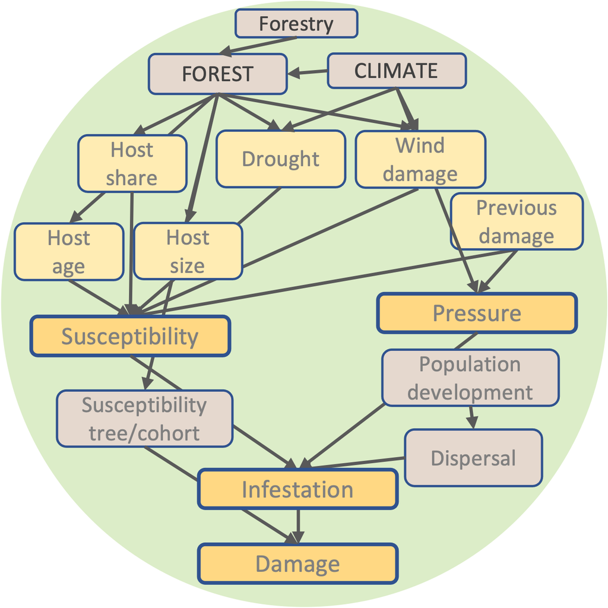

Most of the main processes have alternative formulations where the default corresponds with the approach that was set in the original LandClim beetle sub-module. For those processes where we have implemented more than one formulation, each of them was assigned a complexity value relative to the other formulation in the processes. Then each experiment got a overall complexity value based on the mean complexity value across processes in that experiment. Each of the alternative formulations shown here have a relative complexity assigned to it, where higher values represent higher complexity and lower less complexity. The final value is calculated dividing the relative complexity value by the higher value in that formulation.

## Susceptibility

**Question 1:** What parameters are more important to define forest susceptibility?

**Question 2:** Does it make any difference if we used a more complex definitions for each of the parameters defining forest susceptibility?

### Susceptibility formulations

The susceptibility is defined at the cell level. The overall susceptibility value was calculated with two formulations strategies corresponding to a pre-defined importance of the different parameters defining susceptibility ($S_{cell_{default}}$) and alternative one where the importance of each parameter could be change per experiment ($S_{cell1}$).

[output not shown]

In the experiments we defined the weights to give more importance based on different criteria:

Weigths given in the experiments

[output not shown]

### Drought induced susceptibility ($S_d$)

This parameter defines the drought mediated tree resistance.

[output not shown]

### Spruce age induced susceptibility ($S_a$)

Age is the “dominant” age, the mean age per cell of the host cohorts with diameter larger than 10cm.

### Spruce dbh induced susceptibility ($S_{dbh}$)

The QMD per cell of the cohorts with the host species.

| Attribute | Id | Formulation | Parameters | Complexity | Ref. |
| --- | --- | --- | --- | --- | --- |
| Spruce dbh | $$S_{dbh}$$ | $$S_{dbh}=A +\frac{(1-A)}{1+e^{r(DBH-m)}}$$ | $A=0.23$ $r=0.20488$ $m=26.89512$ | NA | [1] |

### Spruce share induced susceptibility ($S_s$)

| Attribute | Id | Formulation | Param. | Definition | Complexity | Ref. |
| --- | --- | --- | --- | --- | --- | --- |
| Share of beetle host | $$S_{s_{default}}$$ | $$S_s = A + \frac{K-A}{(1+Q*e^{-r*(baSpr -m)})^{1/v}}$$ | $baSpr$= basal area share $$A = 0.08$$ $$K = 1$$ $$Q = 0.2674846$$ $$r = 6.8455438$$ $$m = 0.375$$ $$v = 0.3002734$$ | Determine susceptibility due to beetle host (e.g. spruce) basal area share | 5 | [1] |
| Share of beetle host | $$S_{s_{2}}$$ | $$S_{s} = baSpr$$ | $baSpr$= basal area share | directly correlated with spruce basal area shared | 1 |  |
| Share of beetle host | $$S_{s_{3}}$$ | $$S_s=\begin{cases}0.1 & \text{if}\ baSpr < 0.2\\0.95 & \text{if}\ baSpr >= 0.2\end{cases}$$ | $baSpr$= basal area share |  | 3 |  |
| Share of beetle host | $$S_{s_{4}}$$ | $$S_s=\begin{cases}0.1 & \text{if}\ baSpr < 0.5\\0.95 & \text{if}\ baSpr >= 0.5\end{cases}$$ | $baSpr$= basal area share |  | 3 |  |
| Share of beetle host | $$S_{s_{5}}$$ | $$S_s=\begin{cases}0.1 & \text{if}\ baSpr < 0.7\\0.95 & \text{if}\ baSpr >= 0.7\end{cases}$$ | $baSpr$= basal area share |  | 3 |  |
| Share of beetle host | $$S_{s_{6}}$$ | $$S_s = \frac{1}{1+e^{-r *(BALS -m)}}$$ | $BALS$= basal area share of the largest trees $$r = 12.6776636$$ $$m=0.6806692$$ | basal area of the largest 100 trees (BAL) | 6 | [2] |
| Share of beetle host | $$S_{s_{7}}$$ | $$S_{s} = BALS$$ | $BALS$= basal area share of the largest trees | directly correlated to BAL | 2 |  |
| Share of beetle host | $$S_{s_{8}}$$ | $$S_s=\begin{cases}0.1 & \text{if}\ BALS < 0.2\\0.95 & \text{if}\ BALS >= 0.2\end{cases}$$ | $BALS$= basal area share of the largest trees |  | 4 |  |
| Share of beetle host | $$S_{s_{9}}$$ | $$S_s=\begin{cases}0.1 & \text{if}\ BALS < 0.5\\0.95 & \text{if}\ BALS >= 0.5\end{cases}$$ | $BALS$= basal area share of the largest trees |  | 4 |  |
| Share of beetle host | $$S_{s_{10}}$$ | $$S_s=\begin{cases}0.1 & \text{if}\ BALS < 0.7\\0.95 & \text{if}\ BALS >= 0.7\end{cases}$$ | $BALS$= basal area share of the largest trees |  | 4 |  |

*$baSpr$ is the basal area share [0-1] of spruce trees across all biomass available in the cell including not host trees.

**$BALS$ is the basal area share [0-1] of spruce dominant trees, the 100 largest trees per ha e.g. the 6 largest trees (in dbh) in a 25x25m cell.

The trees should be ordered from larger to smaller diameter and select the $N{trees}$. The number of trees selected should be:

$$N_{trees}=\frac{cellArea*100}{10000}$$

Then $BALS$ in the cell will be:

$$BALS=\frac{\sum_{N_{trees}}^{1} BA}{TotalBA}$$

$TotalBA$ refers to the total BA of all the trees in the cell, also including those that are not beetle host trees.

### Windthrow-induced susceptibility

| Id | Formulation | Param. | Definition | Complexity | Ref. |
| --- | --- | --- | --- | --- | --- |
| $$S_{w_{default}}$$ | $$S_w=\begin{cases}1 & \text{if}\ W_{bhb} / maxW_{bhb} > 1\\W_{bhb} / maxW_{bhb} & \text{else}\ \end{cases}$$ | $W_{bhb}$ Windthrown beetle host biomass in focal cell and year $maxW_{bhb}$ Maximum potential beetle host biomass on cell [t/ha] (user defined) | Wind throw susceptibility index scaled between 0 and 1 per cell and year (S_w) | 1 | [1] |
| $$S_{w2}$$ | $$S_w=\frac{killedwindhostBiomass_{cell}}{totalBiomass_{cell}}$$ |  |  | 2 |  |

#### More explanation on the default formulation

$W_{bhb}$ (windthrowBeetleHostBiomass): Windthrown beetle host biomass in focal cell and year

$maxW_{bhb}$ (maxWindthrowBeetleHost):Maximum potential beetle host biomass on cell [t/ha] ($maxW\_{bhb} = CellmaxBiomass * CellArea * 0.0001 * SiWMaxCoeff[0-1]$

$SiWMaxCoeff$ is a user defined parameter to scale the max biomass proportion that could be considered as the max windthrow beetle host biomass [0-1]

$CellmaxBiomass$ is the max biomass per cell defined by the user in the LandType parameter file, if it is not defined it will take the value 0 and therefore the $S_w$ would be also 1.

#### Time component of wind susceptibility (formulation $S_{w2}$ )

$S_w$ values should be available for two years (current year and the year before), e.g. if the wind damage happened in year t=1, the max value for $S_w$ would be max($S_{w0}$, $S_{w1}$), but even if the max value for t=1 is $S_{w0}$, for t=2 the maximum value would be between max($S_{w1}$, $S_{w2}$), because the the wind-thrown logs are available as host ~2 years (17 months) according to [4].

#### Space component of wind susceptibility (formulation $S_{w2}$ )

| Attribute | Id | Formulation | Parameters | Definition | Ref. | tag |
| --- | --- | --- | --- | --- | --- | --- |
| Neighbour Wind throw-induced susceptibility | $$S_{wn1}$$ | $$S_{wn}=max(1- SiWni)*S_{w_{local}}+ \\ SiWni *maxSiWindNeighbours , \\\text{ } S_{w_{local}})$$ | $W{bhb}$ $maxW_{bhb}$ $SiWMaxCoeff$ $CellmaxBiomass$ | Wind throw susceptibility index scaled between 0 and 1 per cell and year (S_w) | [1] |  |
| Neighbour Wind throw-induced susceptibility | $$S_{wn2}$$ |  |  |  |  |  |

$maxSiWindNeighbour$ is the maximun Swindlocal in a radius of $WIDist$ , calculated with GetNeighbours function

Function to create map of cells within a circle with radius $WIDist$ “dist” (neighbors) around a focal cell.

$WIDist$ is the user defined distance to which the windthrown spruce trees are affecting the neighboring cells, max value of 500m

### Previous year beetle activity induced susceptibility ($S_{A_{t-1}}$)

| Attribute | Id | Formulation | Parameters | Definition | Ref. |
| --- | --- | --- | --- | --- | --- |
| Beetle activity in the previous year in the cell | $S_{A_{t-1}}$ | $$A_{t-1}= \frac{BeetleHostKilled_{t-1}}{BeetleHostBiomass_{t-2}}$$ |  |  |  |

## Pressure

[output not shown]

#### Population development proxy (G)

Relationship between relative degree day sum and beetle hazard (see Figure 6 and 7 in Baier et al. 2007)

| Attribute | Id | Formulation | Param. | Definition | Ref |
| --- | --- | --- | --- | --- | --- |
| Beetle Generations Index at the cell level | $G_{default}$ | $$G = \frac{1}{1+exp(relativeDegreeDaySum-m)}$$ | r = 3.307963 m = 1.980938 |  | [5] |

## Infestation

Spatial extent of infestation at the cell level

| Process | Attribute | Id | Formulation | Param. | Definition | Ref. | tag |
| --- | --- | --- | --- | --- | --- | --- | --- |
| Infestation | Infestation risk at the cell level | $R_{cell}$ | $$R_{cell}=S_{cell}*P_{btl}$$ |  |  | [1] |  |

### Biomass/cell infested

| Attribute | Id | Formulation | Param. | Definition | Ref. | tag |
| --- | --- | --- | --- | --- | --- | --- |
| Infected cell | $B_{inf_{default}}$ | It is based on the maximum biomass that can be infested and ordered by the $R_{cell}$ |  |  |  |  |
| Infected cell | $B_{inf}1$ | $$B_{inf}=Binomial(R_{cell})$$ |  |  | [1] |  |

## Dispersal

##### Beetle generations

| Attribute | Id | Formulation | Parameters | Definition | Ref. |
| --- | --- | --- | --- | --- | --- |
| Generations of beetle in one year | $Gen1$ | $$Gen=\begin{cases}0 & \text{if}\ G=0\\1 & \text{if}\ 0<G<=0.2\\2 & \text{if}\ 0.2<G<=0.6\\3 & \text{if}\ 0.6<G\end{cases}$$ | r = 3.307963 m = 1.980938 | Relationship between relative degree day sum and beetle hazard (see Figure 6 and 7 in Baier et al. 2007) | Baier et al. 2007 and Netherer and Nopp-Mayr 2005. |

If generations take value 2 or 3 then we have dispersal on the same year of 1 or 2 kernels distance respectively.

If the generation value is higher than 1 then we applied the kernel dispersal over the cells that had an infestation.

| Attribute | Id | Formulation | Param. | Definition | Ref. |
| --- | --- | --- | --- | --- | --- |
| Beetle dispersal if Generations is >1 | $K$ | $$K=e^-({\frac{\frac{D}{4.5}}{40.5*4}})^2$$ | $D$ = distance in (m) |  | iLand formulation Fahse and Heurich 2011 |

The $K$ value used will be the highest value of the cell, in case this cell is exposed to higher pressure (K values) from nearby cells that were already infected.

The kernel is scaled (values sum more than one) and the value is used to substitude the Pressure of the cells with a kernel value:

$$R_{cell}=S_{cell}*K$$

When the new $R_{cell}$ value is calculated for the cells that were not previously infected and exposed to a K value, then we will run again:

$$B_{inf}=Binomial(R_{cell})$$

only for those cells that were not previously infected.

When all of this is done we will have a final map identifying which cells are infected by beetle and which ones are not, and we can move to the “kill” trees using the mortality formulation.

$D$ will take a maximum value of 50m so the kernel wont be as large as the whole landscape.

## Mortality

| Attribute | Id | Formulation | Param. | Definition | Ref. |
| --- | --- | --- | --- | --- | --- |
| Mortality | $M_{btl_{default}}$ * | $$M_{btl}=\frac{S_{coh}+P_{btl}}{2}$$ |  |  |  |
| Mortality | $M_{btl1}$ | $$M_{btl}=S_{coh}*R_{cell}$$ |  |  |  |

Then the number of trees killed in each cohort is defined as:

$$Killed_{cohort}=Binomial(M_{btl}, N_{cohort})$$

| Attribute | Id | Formulation | Param. | Complexity | Ref. |
| --- | --- | --- | --- | --- | --- |
|  | $default$ | $$S_{coh}=\frac{S_{d}+S_{a_{coh}}}{2}$$ |  | 1 | [1] |
| Cohort susceptibility to being killed | $S_{coh_{default}}$ | $$S_{coh}=max(\frac{S_{d}+S_{a_{coh}}}{2}, S_{wn})$$ |  | 2 |  |
| Cohort susceptibility to being killed | $S_{coh}1$ | $$S_{coh}=max(\frac{S_{d}+S_{dbh_{coh}}}{2}, S_{wn})$$ |  | 2 |  |
| Cohort susceptibility to being killed | $S_{coh}2$ | $$S_{coh}=wS_{d_{coh}}*S_{d}+\\wS_{dbh_{coh}}*S_{dbh_{coh}} +\\ wS_{wn}* S_{wn} +\\ wS_{a_{coh}} * S_{a_{coh}}$$ | $w$ = weight applied to the susceptibility $ S_{d_{coh}} $ = droughsusceptibility at the cohort level | 3 |  |

## References

[1] Temperli 2013

[2] Temperli 2015

[3] Netherer and Nopp-Mayr * Swind is using the weight assigned in this paper to predisposition index stand density

[4] Louis, M., Grégoire, J.-C. & Pélisson, P.-F. Exploiting fugitive resources: How long-lived is ‘“fugitive”’? Fallen trees are a long-lasting reward for Ips typographus (Coleoptera, Curculionidae,Scolytinae). *Forest Ecology and Management* doi:http://dx.doi.org/10.1016/j.foreco.2014.08.009.

[5] Baier et al. 2007 and Netherer and Nopp-Mayr 2005.